# Practical Machine Learning Course Project

James Van Campen

October 26, 2014

## Human Activity Recognition

### Synopsis

This report presents the process of developing and applying a prediction algorithm to human activity data. Specifically, weight lifting exercise (WLE) data is analyzed. Each record represents one lift (arm curl). Each lift has a “classe” value (A, B, C, D, or E). When classe equals A the lift was done correctly, Values B, C, D, and E each represent a specific way of doing the lift incorrectly. Six different people performed the exercises and data was collected from motion sensors mounted on their arms, forearms, waists, and the dumbbells. A training data set with 19622 records is used to develop a prediction model for classe. The model is then applied to a test data set with 20 records.

# Downloading and Subsetting the Data

The training and testing data files are downloaded separately. The training data is then split into two files for model development purposes (60% training and 40% testing). For additional background on the WLE data see this link.

http://groupware.les.inf.puc-rio.br/har

```r
# Download training and test data
# URLtrain <- "https://d396qusza40orc.cloudfront.net/predmachlearn/pml-training.csv"
# URLtest <- "https://d396qusza40orc.cloudfront.net/predmachlearn/pml-testing.csv"
# download.file(URLtrain,destfile=".\\pml_train.csv")
# download.file(URLtest,destfile=".\\pml_test.csv")
ptr1 <- read.csv(file=".\\pml_train.csv")
pte1 <- read.csv(file=".\\pml_test.csv")
# Subset create training (60%) and testing (40%) data sets from training data
library(caret)
library(randomForest)
set.seed(12321)
intrain <- createDataPartition(y=ptr1$classe,p=.6,list=F)
train1 <- ptr1[intrain,]
test1 <- ptr1[-intrain,]
```

# Exploratory Analysis

```r
# Quick peek at data
# dim(train1)
# names(train1)
# table(train1$classe,train1$user_name)
# summary(train1)
```

Output from the summary function reveals that many variables in the training data set are missing exactly 11529 values. Since that represents 98% of the rows in the training data set, those variables will be dropped from the analysis.

```r
# Create list of variables with 11529 missing values
# Put output from summary in a data frame and convert the Freq variable to character
meta1 <- data.frame(summary(train1))
meta1$Freq <- as.character(meta1$Freq)
# Get the names of the variables where there are 11529 missing values
# gsub used to remove some leading spaces from the names
misslist <- gsub(" ","", as.character(meta1[grep("11529",meta1$Freq),2]))
# Create data file with only variables of interest
keeplist <- names(train1)[!(names(train1) %in% misslist)]
train2 <- train1[,keeplist]
# Remove X, raw_timestamp_part_1, raw_timestamp_part_2, cvtd_timestamp, num_window,
# and user_name
train2 <- train2[,7:59]
```

### Tree Classification Model

First try a classification tree to get a sense of how well that works.

```r
modfit <- train(classe~.,method="rpart", data=train2)
print(modfit$finalModel)
```

```
## n= 11776
##
## node), split, n, loss, yval, (yprob)
##       * denotes terminal node
##
##  1) root 11776 8428 A (0.28 0.19 0.17 0.16 0.18)
##    2) roll_belt< 130.5 10806 7468 A (0.31 0.21 0.19 0.18 0.11)
##      4) pitch_forearm< -34.55 921    4 A (1 0.0043 0 0 0) *
##      5) pitch_forearm>=-34.55 9885 7464 A (0.24 0.23 0.21 0.2 0.12)
##       10) roll_forearm< 124.5 6308 4125 A (0.35 0.24 0.16 0.19 0.068)
##         20) magnet_dumbbell_y< 432.5 5176 3052 A (0.41 0.18 0.18 0.17 0.058) *
##         21) magnet_dumbbell_y>=432.5 1132  552 B (0.052 0.51 0.034 0.29 0.12) *
##       11) roll_forearm>=124.5 3577 2513 C (0.067 0.21 0.3 0.21 0.22) *
##    3) roll_belt>=130.5 970   10 E (0.01 0 0 0 0.99) *
```

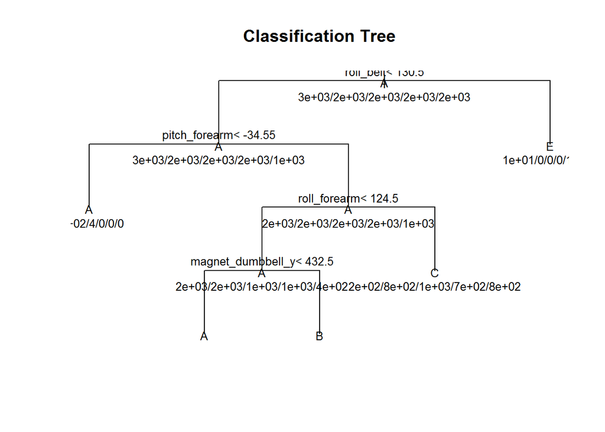

```r
plot(modfit$finalModel,uniform=T,main="Classification Tree")
text(modfit$finalModel,use.n=T, all=T, cex=.8)
```

```r
pred1 <- predict(modfit,newdata=train2)
table(pred1,train2$classe)
```

```
##
## pred1    A    B    C    D    E
##     A 3041  948  951  858  299
##     B   59  580   39  323  131
##     C  238  751 1064  749  775
##     D    0    0    0    0    0
##     E   10    0    0    0  960
```

```r
accuracy1 <- sum(diag(table(pred1,train2$classe))) / dim(train2)[1]
accuracy1
```

```
## [1] 0.4794
```

The in-sample accuracy of the classification tree is 48%. Let us see if we can improve upon this by preprocessing using principal components analysis (PCA) and using the random forest method.

### Random Forest with PCA

The model is fit to the training data using the random forest model method. All 52 principal components were used since it does not seem to slow down the calculations to include them, and it does improve the accuracy a little.

```r
# Only 24 principle components are required to capture 95% of the variance
# 52 pc's were used since it did not take much time and improved the results
pp1 <- preProcess(train2[,-53],method="pca",pcaComp=52)
trainpc <- predict(pp1,train2[,-53])
mfit <- randomForest(train2$classe~., data=trainpc, ntree=500)
mfit
```

```
##
## Call:
##  randomForest(formula = train2$classe ~ ., data = trainpc, ntree = 500)
##                Type of random forest: classification
##                      Number of trees: 500
## No. of variables tried at each split: 7
##
##         OOB estimate of  error rate: 2.73%
## Confusion matrix:
##      A    B    C    D    E class.error
## A 3334    8    0    3    3    0.004182
## B   66 2172   32    2    7    0.046950
## C    5   37 1989   20    3    0.031646
## D    3    3   86 1832    6    0.050777
## E    0   10   19    8 2128    0.017090
```

```r
cv1 <- rfcv(trainpc,train2$classe)
cv1$error.cv
```

```
##      52      26      13       6       3       1
## 0.02947 0.03626 0.05435 0.12670 0.44030 0.73871
```

### Apply Random Forest Model to Testing Data

```r
# Remove extra variables
test2 <- test1[,keeplist]
test2 <- test2[,7:59]
testpc <- predict(pp1,test2[,-53])
mfit2 <- randomForest(test2$classe~., data=testpc, ntree=500)
mfit2
```

```
##
## Call:
##  randomForest(formula = test2$classe ~ ., data = testpc, ntree = 500)
##                Type of random forest: classification
##                      Number of trees: 500
## No. of variables tried at each split: 7
##
##         OOB estimate of  error rate: 3.54%
## Confusion matrix:
##      A    B    C    D    E class.error
## A 2219    9    2    1    1    0.005824
## B   57 1431   26    1    3    0.057312
## C    3   37 1316   10    2    0.038012
## D    3    2   78 1195    8    0.070762
## E    1   10   11   13 1407    0.024272
```

```r
cv2 <- rfcv(testpc,test2$classe)
cv2$error.cv
```

```
##      52      26      13       6       3       1
## 0.04155 0.04805 0.07239 0.17589 0.44876 0.74407
```

The estimated error from cross validation with the testing data is .042. The expected number of incorrect predictions out of twenty tries is approximately one.

### Making the Twenty Test Predictions

```r
pte2 <- pte1[,keeplist[-59]]
pte2 <- pte2[,7:58]
pte2pc <- predict(pp1,pte2)
pred2 <- predict(mfit2,pte2pc)
pred2
```

```
##  1  2  3  4  5  6  7  8  9 10 11 12 13 14 15 16 17 18 19 20
##  C  A  B  A  A  E  D  B  A  A  B  C  B  A  E  E  A  B  B  B
## Levels: A B C D E
```

```r
table(pred2)
```

```
## pred2
## A B C D E
## 7 7 2 1 3
```